# Linear models and interaction effects

Rob Davies

Department of Psychology, Lancaster University

## PSYC122: Classes in weeks 16-20

- My name is Dr Rob Davies, I am an expert in communication, individual differences, and methods

**Tip**

**Ask me anything**:

- questions during class in person or anonymously through slido;
- all other questions on discussion forum

## Week 19: Linear models – interactions and variation in effects

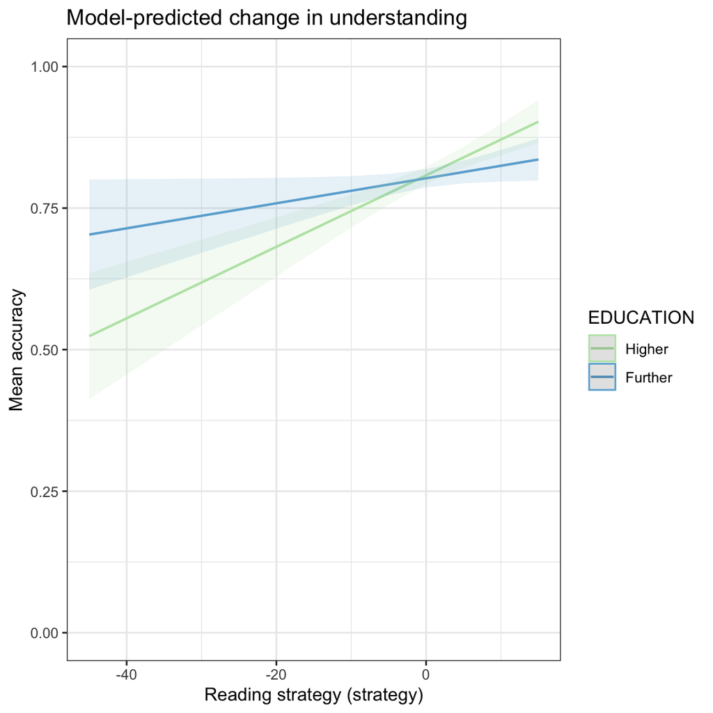

Figure 1: Plot showing how the effect of reading strategy on accuracy varies at different education levels, given an interaction between the effects of reading strategy and education level

## Targets for weeks 16-19: Concepts

We are working together to develop concepts:

1. *Week 16* — Hypotheses, measurement and associations
2. *Week 17* — Predicting people using linear models
3. *Week 18* — Everything is some kind of linear model
4. *Week 19* — **The real challenge in psychological science**

## Targets for weeks 16-19: Skills

We are working together to develop skills:

1. *Week 16* — Visualizing, estimating, and reporting associations
2. *Week 17* — Using data to *predict* people
3. *Week 18* — Going deeper on linear models
4. *Week 19* — **Evaluating how effects vary**

## Learning targets for this week

*Concepts* – To engage with the real challenge in psychological science:

1. People vary
2. Effects vary
3. Results vary
- This means we have to think about what Psychologists call *interaction effects*

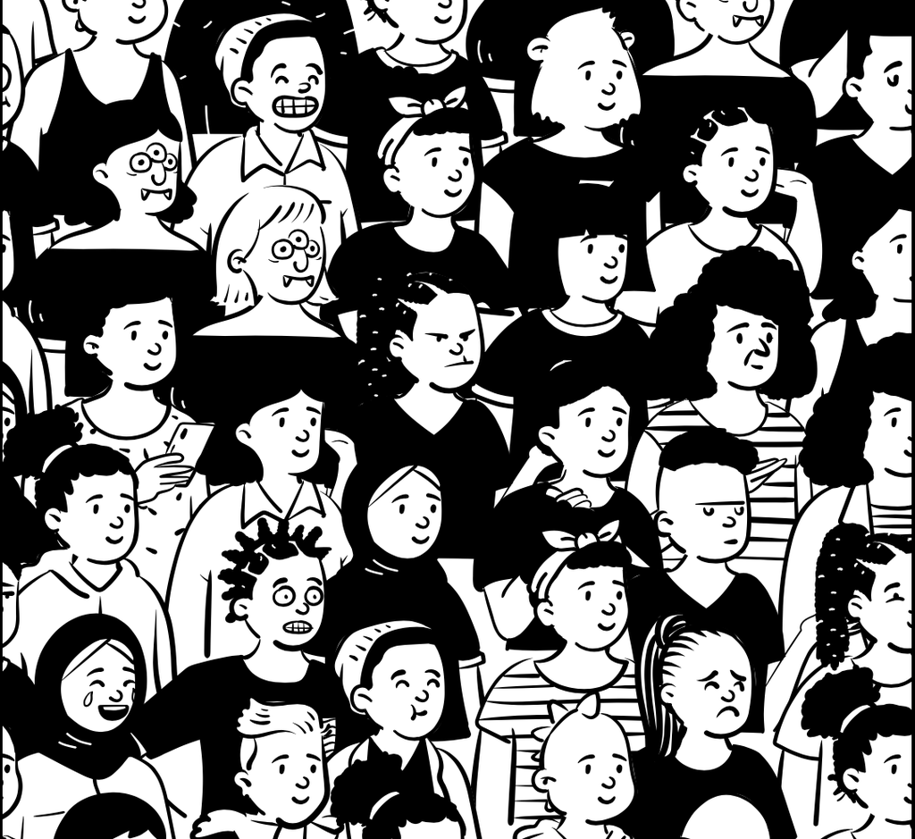

Crowd of people; open-peeps

## Learning targets for this week

*Skills* – To be able to code linear models that include interaction effects:

```r
lm(outcome.Y ~ predictor.X*predictor.Z)
```

## Learning targets for this week

*Skills* – To be able to *visualize*, interpret, and report tests of interaction effects:

```r
# -- fit model
data.lm.acc <- lm(mean.acc ~ strategy_centered*EDUCATION, data = data)

# -- make plot of predictions
plot_model(data.lm.acc, type = "pred",
           terms = c("strategy_centered", "EDUCATION"))
```

## Why are these our targets? Because people vary, effects vary, results vary

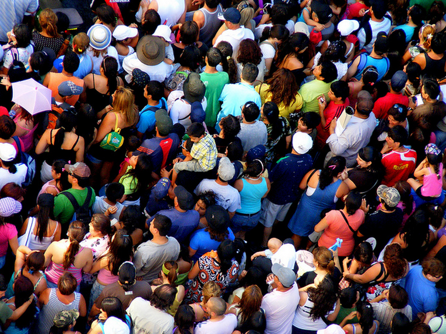

flickr, Cat Walker ‘crowd’

## Critical thinking: Variation

> Psychological and social processes show much more variability than the usual phenomena in the physical sciences (Gelman, 2015)
- The patterns that interest us **will vary** between places, people, and contexts
- **Because** the effects of interventions, treatments or experimental manipulations can be expected to vary
- We **must** build the ability to investigate **how** those effects vary

## Critical thinking: Uncertainty

Human variation means that there are three levels of **uncertainty** when we look at sample data (McElreath, 2020):

1. The nature of the expected change in outcome $\rightarrow$ what variables predict average outcome variation?
2. The ways that expected changes might vary between individual participants or between groups of participants $\rightarrow$ what differences are there between individuals or groups?
3. The random ways that specific responses can be produced $\rightarrow$ how much can we predict anyone’s behaviours?

## Critical thinking: Working with samples

We often test who we can – convenience sampling – and who we can test has an impact on the quality of our evidence (Bornstein et al., 2013)

**Critical evaluation**

- If the people in our samples vary in age, education, ethnicity or gender $\rightarrow$
- Does the presence of sub-groups or of individual differences within or between our samples matter?
- If it does matter, *how or why* does it matter?
- We examine these questions in the context of the health comprehension project

## Let’s take a break

- End of part 1

## Health comprehension project – finding answers to our questions

- We have been working in the context of a live research project: *What makes it easy or difficult to understand written health information?*

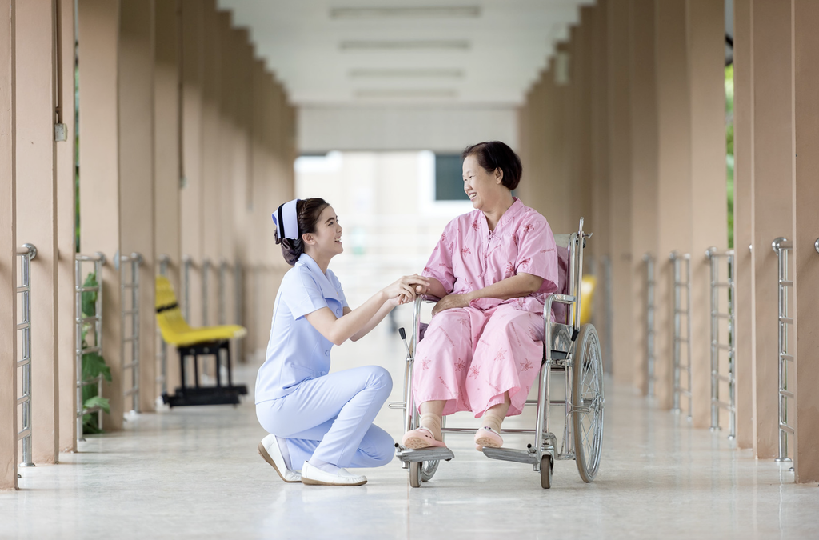

flickr, Sasin Tipchair ‘Senior woman in wheelchair talking to a nurse in a hospital’

## Health comprehension project: questions and analyses

- Our research questions are:

**Note**

1. What person attributes predict success in understanding?
2. Can people accurately evaluate whether they correctly understand written health information?

## Theory: Models of comprehension accuracy *should* include as predictors:

(1.) experience `HLVA, SHIPLEY` and (2.) reasoning ability (`strategy`, reading strategy) (Freed et al., 2017)

## Multiple potential predictor variables

It will become important that we distinguish between numeric variables (like age) and categorical variables (*factors* like education level)

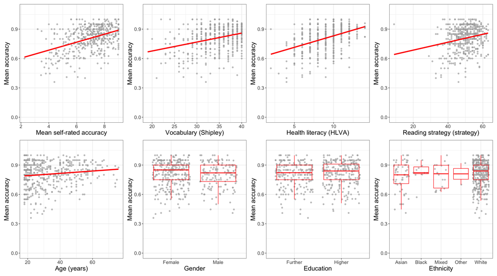

Figure 3: Scatterplots showing the potential association between accuracy of comprehension and variation on each of a series of potential predictor variables.

## *What* effects could vary?

- The effect of an intervention or treatment
- The effect of an experimental manipulation
- The effect of the difference between groups
- The characteristics of an association between an outcome and a predictor

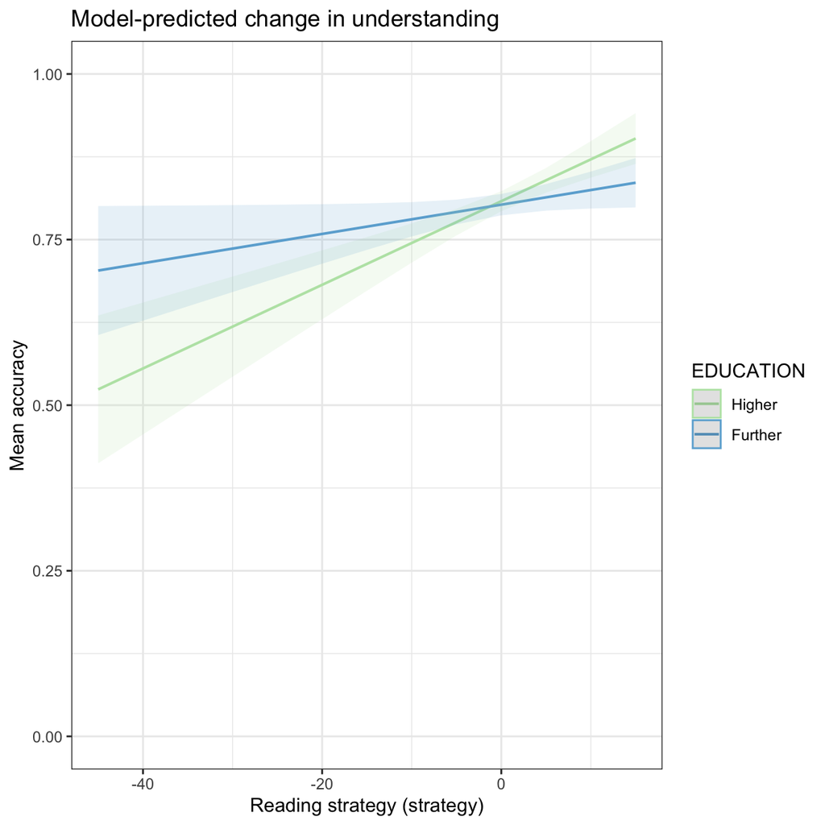

Figure 4: How the effect of reading strategy on accuracy varies at different education levels

## *How* could effects vary?

- We are focusing, here, on the shape and size of an effect
- The shape and size of an effect is shown by the coefficient estimate
- The coefficient estimate indicates the slope of the line
- The slope predicts how the outcome will change, given variation in predictor values

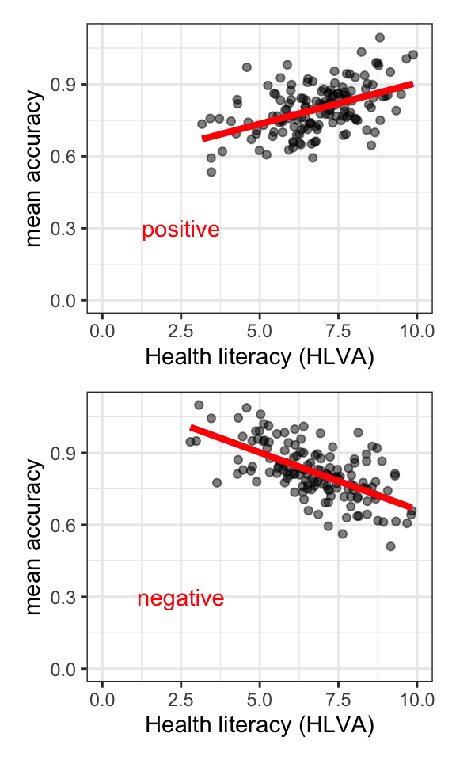

## *How* could effects vary?

- Is the effect (the slope) positive or negative in direction (see Figure 6): does the line go up (effect is positive) or down (effect is negative)?
- Is the effect small, or large, or moderate in size: does the slope go up or down steeply (larger effect) or at a shallow angle (smaller effect)?

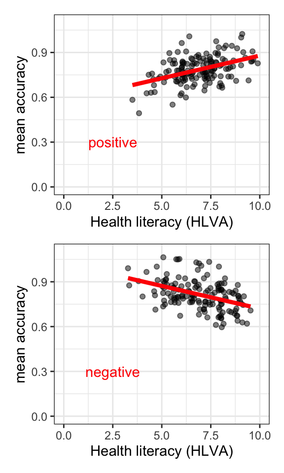

## *How* could effects vary?

**Tip**

Is the shape or size of an effect different in different groups of people, in different contexts, or for different values of a third variable (a *moderator*)?

- We can answer questions like these by building models that include *interaction effects*
- We learn how to do that *next*

## How do we code a model so that it includes an interaction effect?

- **If** we think that the shape or size of an effect is different in different groups of people, or in different contexts, or for different values of a third variable (a *moderator)*
- **Then** we think that there is an **interaction**
- It helps to understand what this means by first working with an example and then working with a little algebra

## Theory of an interaction

- **Hypothesis**: the impact of knowing about health matters (health literacy, measured using the `HLVA`) will *interact* with the impact of having broad vocabulary knowledge (measured using the `SHIPLEY`)
- **Theory 1**: the effect (slope) of health literacy will be *amplified* (made steeper) for people who already know about language (and score high on the `SHIPLEY`)
- *because* wider general knowledge improves the capacity to work with specialist (health) information

## Theory of an interaction

- **Hypothesis**: the impact of knowing about health matters (health literacy, measured using the `HLVA`) will *interact* with the impact of having broad vocabulary knowledge (measured using the `SHIPLEY`)
- **Theory 2**: the effect (slope) of health literacy will be *reduced* (made more shallow) for people who already know about language (and score high on the `SHIPLEY`)
- *because* if you are already doing well (on outcome comprehension) the room for improvement (with more specialist health knowledge) decreases

## Visualisation of an interaction

The way that

1. the *slope* for the relation between outcome `mean.acc` and predictor `HLVA`
2. differs *depending on*
3. differences in values of the third variable `SHIPLEY`

$\rightarrow$ This is what makes a possible *interaction*

## Let’s take a break

- End of part 2

## Coding models with interactions

```r
lm(mean.acc ~ HLVA*SHIPLEY, data = data)
```

## Revision: Using linear models for prediction

- With the linear model `lm(mean.acc ~ SHIPLEY)`
- We can predict change in mean comprehension accuracy (`mean.acc`)
- Given variation in vocabulary scores (`SHIPLEY`)

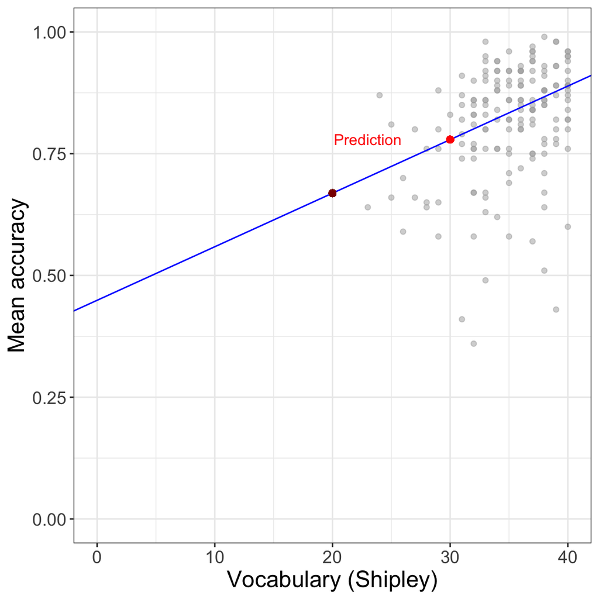

## Revision: Differences between predictions and observations

- Higher vocabulary scores are associated with higher accuracy scores
- Model predictions are circled in black along the blue line
- Light grey lines indicate differences between predicted and observed outcomes

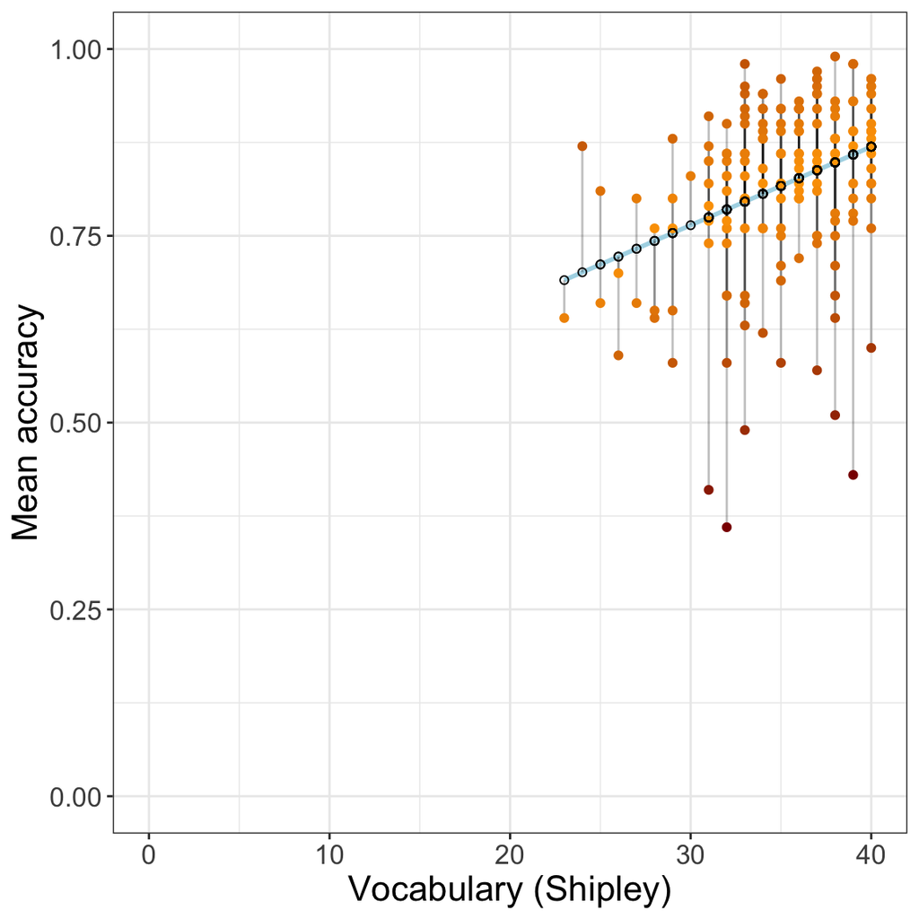

## Revision: Assume residuals are normally distributed

- The plot shows the distribution of residuals, as a histogram in grey
- The peak of the distribution is centered at residuals = 0
- The red curve show what the distribution of residuals would look like if it was perfectly normal

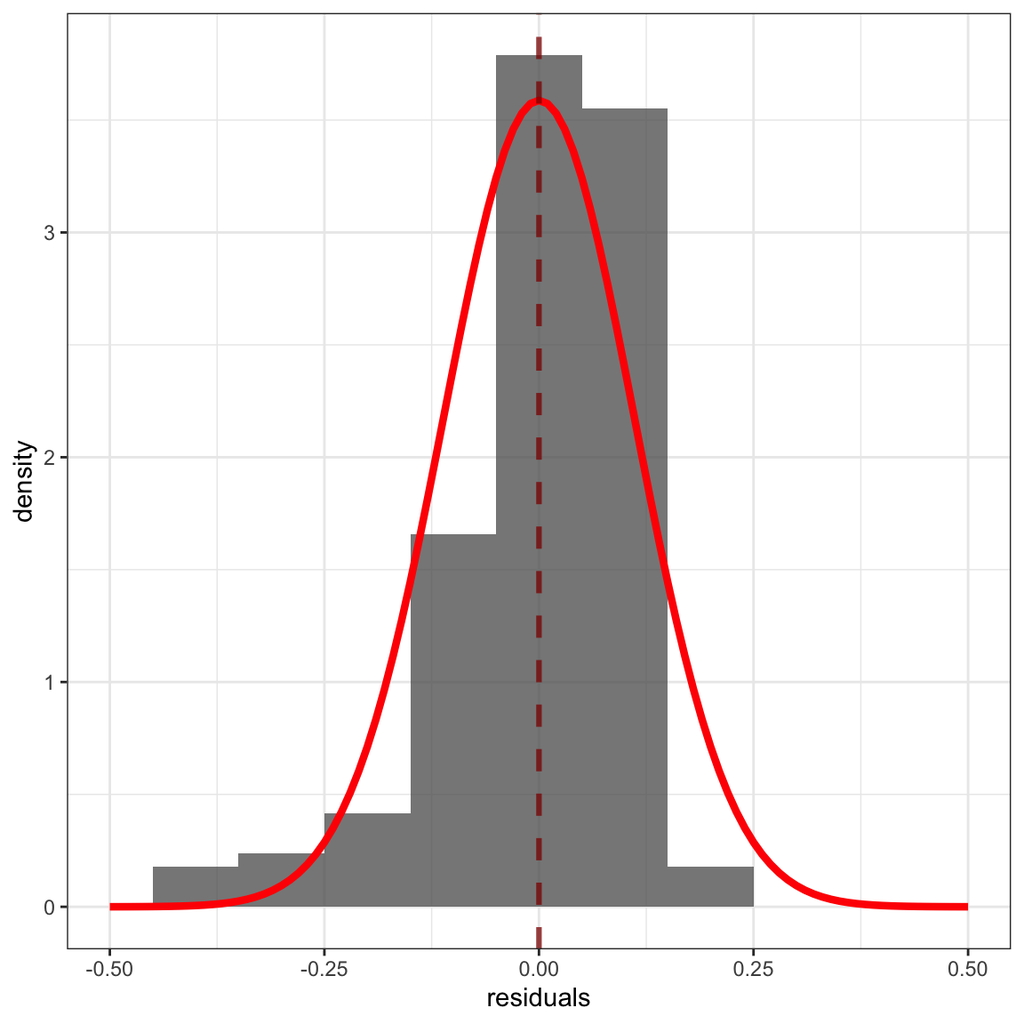

## Revision: Previously, we have looked at coding the linear model with multiple predictors

```r
lm(mean.acc ~ SHIPLEY + HLVA + strategy + AGE + NATIVE.LANGUAGE, ...)
```

- The code represents a linear model with multiple predictors:
- $y = \beta_0 + \beta_1x_1 + \beta_2x_2 + \dots + \epsilon$

## Revision: For a linear model with multiple predictors, we see

```
Call:
lm(formula = mean.acc ~ SHIPLEY + HLVA + strategy + AGE, data = all.data)

Residuals:
     Min       1Q   Median       3Q      Max
-0.38654 -0.07169  0.01129  0.07683  0.31901

Coefficients:
              Estimate Std. Error t value Pr(>|t|)
(Intercept)  3.891e-01  4.856e-02   8.013 8.80e-15 ***
SHIPLEY      4.975e-03  1.325e-03   3.754 0.000196 ***
HLVA         1.831e-02  2.582e-03   7.090 4.92e-12 ***
strategy     1.736e-03  7.974e-04   2.177 0.029984 *
AGE         -7.984e-05  3.954e-04  -0.202 0.840082
---
Signif. codes:  0 '***' 0.001 '**' 0.01 '*' 0.05 '.' 0.1 ' ' 1

Residual standard error: 0.1124 on 473 degrees of freedom
Multiple R-squared:  0.2082,    Adjusted R-squared:  0.2015
F-statistic: 31.09 on 4 and 473 DF,  p-value: < 2.2e-16
```

1. The Coefficient `Estimate`: for the slope of the effect of variation in each predictor
2. The `Std. Error` (standard error) for the estimate of each effect
3. The `t value` and `Pr(>|t|)` p-value for null hypothesis tests of each coefficient

## Revision: Thinking about the linear model with multiple predictors

$y = \beta_0 + \beta_1x_1 + \beta_2x_2 + \dots + \epsilon$

Outcome $y$ is calculated as a sum by adding together:

- The intercept $\beta_0$ plus
- The product of the coefficient of the effect of e.g. `AGE` $\beta_1$ multiplied by $x_1$ a person’s age `+`
- `+` any number of other variables `+`
- The error $\epsilon$: mismatches between observed and predicted outcomes

## New: Thinking about the linear model with multiple predictors as an *additive* model

$y = \beta_0 + \beta_1x_1 + \beta_2x_2 + \dots + \epsilon$

**Note**

Models like this are said to be additive because

- The relation between the outcome variable (here, `mean.acc`) for any one predictor (e.g., the relation between `mean.acc` and `HLVA`)
- Is *constant* over all values of the other predictor
- In our example, this means the relation between `mean.acc` and `HLVA` would be the same whatever the value of `SHIPLEY`.

## New: Now, we code models with interactions

- For discussion, we consider an example model in which we focus on the interaction between the effects of health literacy (`HLVA`) and vocabulary knowledge (`SHIPLEY`)
- We can specify interactions in two different ways:
1. Using `*`

```r
lm(mean.acc ~ HLVA*SHIPLEY, data = data)
```

2. Using `:`

```r
lm(mean.acc ~ HLVA + SHIPLEY + HLVA:SHIPLEY, data = data)
```

## Identifying key information in results: for a model including an interaction

```r
model <- lm(mean.acc ~ HLVA*SHIPLEY, data = all.data)
summary(model)
```

```
Call:
lm(formula = mean.acc ~ HLVA * SHIPLEY, data = all.data)

Residuals:
     Min       1Q   Median       3Q      Max
-0.37986 -0.06840  0.01342  0.07652  0.29872

Coefficients:
              Estimate Std. Error t value Pr(>|t|)
(Intercept)  0.4806201  0.1445375   3.325 0.000952 ***
HLVA         0.0153042  0.0168363   0.909 0.363810
SHIPLEY      0.0045132  0.0043491   1.038 0.299919
HLVA:SHIPLEY 0.0001132  0.0004922   0.230 0.818173
---
Signif. codes:  0 '***' 0.001 '**' 0.01 '*' 0.05 '.' 0.1 ' ' 1

Residual standard error: 0.1128 on 474 degrees of freedom
Multiple R-squared:  0.2004,    Adjusted R-squared:  0.1953
F-statistic: 39.59 on 3 and 474 DF,  p-value: < 2.2e-16
```

## Identifying key information in results: for a model including an interaction

You see each `Estimate` for the `Coefficients:` – the effects of:

1. `HLVA`
2. `SHIPLEY`
3. The `HLVA:SHIPLEY` coefficient for the **interaction** tells us how the slope of the `HLVA` effect varies – depending on `SHIPLEY` scores

```r
model <- lm(mean.acc ~ HLVA*SHIPLEY, data = all.data)
summary(model)
```

```
Call:
lm(formula = mean.acc ~ HLVA * SHIPLEY, data = all.data)

Residuals:
     Min       1Q   Median       3Q      Max
-0.37986 -0.06840  0.01342  0.07652  0.29872

Coefficients:
              Estimate Std. Error t value Pr(>|t|)
(Intercept)  0.4806201  0.1445375   3.325 0.000952 ***
HLVA         0.0153042  0.0168363   0.909 0.363810
SHIPLEY      0.0045132  0.0043491   1.038 0.299919
HLVA:SHIPLEY 0.0001132  0.0004922   0.230 0.818173
---
Signif. codes:  0 '***' 0.001 '**' 0.01 '*' 0.05 '.' 0.1 ' ' 1

Residual standard error: 0.1128 on 474 degrees of freedom
Multiple R-squared:  0.2004,    Adjusted R-squared:  0.1953
F-statistic: 39.59 on 3 and 474 DF,  p-value: < 2.2e-16
```

## We need to use algebra to make sense of what we see

The standard way to represent an interaction in algebra is:

$$y \sim \beta_0 + \beta_1X + \beta_2Z + \color{red}{\beta_3XZ} + \epsilon$$

For this model, the average change in the outcome, $y$, is calculated by adding together:

- the values for $\beta_0$ the intercept plus
- $\beta_1X$ the effect of X (for some value of X) *plus*
- $\beta_2Z$ the effect of Z (for some value of Z) *plus*
- $\color{red}{\beta_3XZ}$ the effect of XZ the **interaction**

## What is the interaction term doing?

$$y \sim \beta_0 + \beta_1X + \beta_2Z + \color{red}{\beta_3XZ} + \epsilon$$

To make this concrete, we can translate this model using the variables from our example data:

$$\begin{aligned}
mean.acc &= {\beta_0} + {\beta}_{1}(HLVA) + {\beta}_{2}(SHIPLEY)\ + \\
&\quad {\beta}_{3}(HLVA \times SHIPLEY) + \epsilon
\end{aligned}$$

- $\beta_0$ the intercept
- $\beta_1X$ the effect of `HLVA`
- $\beta_2Z$ the effect of `SHIPLEY`
- $\color{red}{\beta_3XZ}$ the effect of `HLVA:SHIPLEY` the **interaction**

## What is the interaction term doing?

$$y \sim \beta_0 + \beta_1X + \beta_2Z + \color{red}{\beta_3XZ} + \epsilon$$

$$mean.acc = \alpha + \beta_{1}(HLVA) + \beta_{2}(SHIPLEY) + \beta_{3}(HLVA \times SHIPLEY) + \epsilon$$

- Here, $\beta_1$ reflects the influence of `HLVA` on outcome `mean.acc` when `SHIPLEY` = 0.
- $\beta_2$ reflects the influence of `SHIPLEY` on outcome `mean.acc` when `HLVA` = 0.
- $\color{red}{\beta_3}$ reflects the **change in the effect** of `HLVA` on outcome `mean.acc`, given different values of `SHIPLEY`

## What is the interaction term doing?

The key idea here is that the effect of one predictor variable (`HLVA`) on the outcome is a function of another predictor variable (`SHIPLEY`)

- The slope $\beta_1$ of the effect of the predictor $HLVA$ changes
- by the amount $\beta_3$, for unit change in $SHIPLEY$ values

## What is the interaction term doing?

We can state an equation for calculating the slope of the predicted effect of $HLVA$ on outcome $mean.acc$ at any value of $SHIPLEY$ as:

$$The \space HLVA \space slope \space at \space some \space SHIPLEY \space score = \beta_1 + \beta_3 \times SHIPLEY$$
In the presence of an interaction, the effect of the predictor `HLVA` is a **composite** reflecting

- the impact of variation in health literacy ($\beta_1$)
- *and* how that effect is modified ($\beta_3$) for different values of the moderator `SHIPLEY`

## Interactions are symmetrical

- In our example, we started by looking at the `HLVA*SHIPLEY` interaction
- But equally we could consider the `SHIPLEY*HLVA` interaction

```r
model <- lm(mean.acc ~ SHIPLEY*HLVA, data = all.data)
summary(model)
```

```
Call:
lm(formula = mean.acc ~ SHIPLEY * HLVA, data = all.data)

Residuals:
     Min       1Q   Median       3Q      Max
-0.37986 -0.06840  0.01342  0.07652  0.29872

Coefficients:
              Estimate Std. Error t value Pr(>|t|)
(Intercept)  0.4806201  0.1445375   3.325 0.000952 ***
SHIPLEY      0.0045132  0.0043491   1.038 0.299919
HLVA         0.0153042  0.0168363   0.909 0.363810
SHIPLEY:HLVA 0.0001132  0.0004922   0.230 0.818173
---
Signif. codes:  0 '***' 0.001 '**' 0.01 '*' 0.05 '.' 0.1 ' ' 1

Residual standard error: 0.1128 on 474 degrees of freedom
Multiple R-squared:  0.2004,    Adjusted R-squared:  0.1953
F-statistic: 39.59 on 3 and 474 DF,  p-value: < 2.2e-16
```

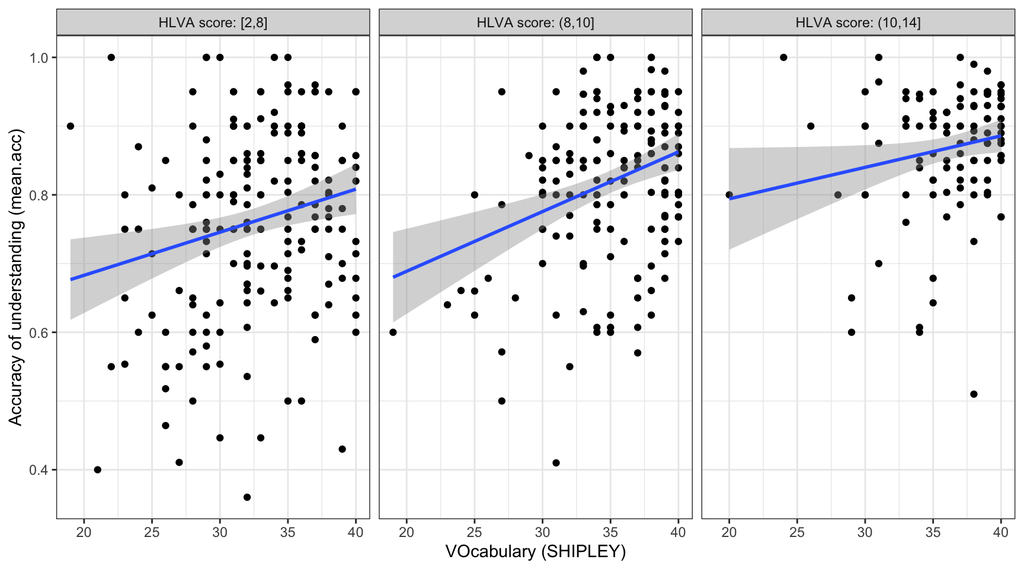

Figure 9: The relation between SHIPLEY and mean.acc for different ranges of HLVA scores

## Evaluation of an interaction

- In our example, there is *some* variation in the slope of the `HLVA` effect for different ranges of `SHIPLEY`
- And *some* variation in the slope of the `SHIPLEY` effect for different ranges of `HLVA`
- But either way the interaction is **not significant**: `p > .05` for the interaction

```r
model <- lm(mean.acc ~ HLVA*SHIPLEY, data = all.data)
summary(model)
```

```
Call:
lm(formula = mean.acc ~ HLVA * SHIPLEY, data = all.data)

Residuals:
     Min       1Q   Median       3Q      Max
-0.37986 -0.06840  0.01342  0.07652  0.29872

Coefficients:
              Estimate Std. Error t value Pr(>|t|)
(Intercept)  0.4806201  0.1445375   3.325 0.000952 ***
HLVA         0.0153042  0.0168363   0.909 0.363810
SHIPLEY      0.0045132  0.0043491   1.038 0.299919
HLVA:SHIPLEY 0.0001132  0.0004922   0.230 0.818173
---
Signif. codes:  0 '***' 0.001 '**' 0.01 '*' 0.05 '.' 0.1 ' ' 1

Residual standard error: 0.1128 on 474 degrees of freedom
Multiple R-squared:  0.2004,    Adjusted R-squared:  0.1953
F-statistic: 39.59 on 3 and 474 DF,  p-value: < 2.2e-16
```

## Let’s take a break

- End of part 3

## Interactions between numeric variables and factors

```r
data.lm.acc <- lm(mean.acc ~ EDUCATION*strategy,
                  data = all.data)
summary(data.lm.acc)
```

```
Call:
lm(formula = mean.acc ~ EDUCATION * strategy, data = all.data)

Residuals:
     Min       1Q   Median       3Q      Max
-0.43422 -0.06111  0.01700  0.09208  0.23754

Coefficients:
                          Estimate Std. Error t value Pr(>|t|)
(Intercept)               0.692571   0.054831  12.631   <2e-16 ***
EDUCATIONHigher          -0.199280   0.083325  -2.392   0.0172 *
strategy                  0.002210   0.001100   2.008   0.0452 *
EDUCATIONHigher:strategy  0.004104   0.001656   2.479   0.0135 *
---
Signif. codes:  0 '***' 0.001 '**' 0.01 '*' 0.05 '.' 0.1 ' ' 1

Residual standard error: 0.1223 on 474 degrees of freedom
Multiple R-squared:  0.06106,   Adjusted R-squared:  0.05512
F-statistic: 10.28 on 3 and 474 DF,  p-value: 1.45e-06
```

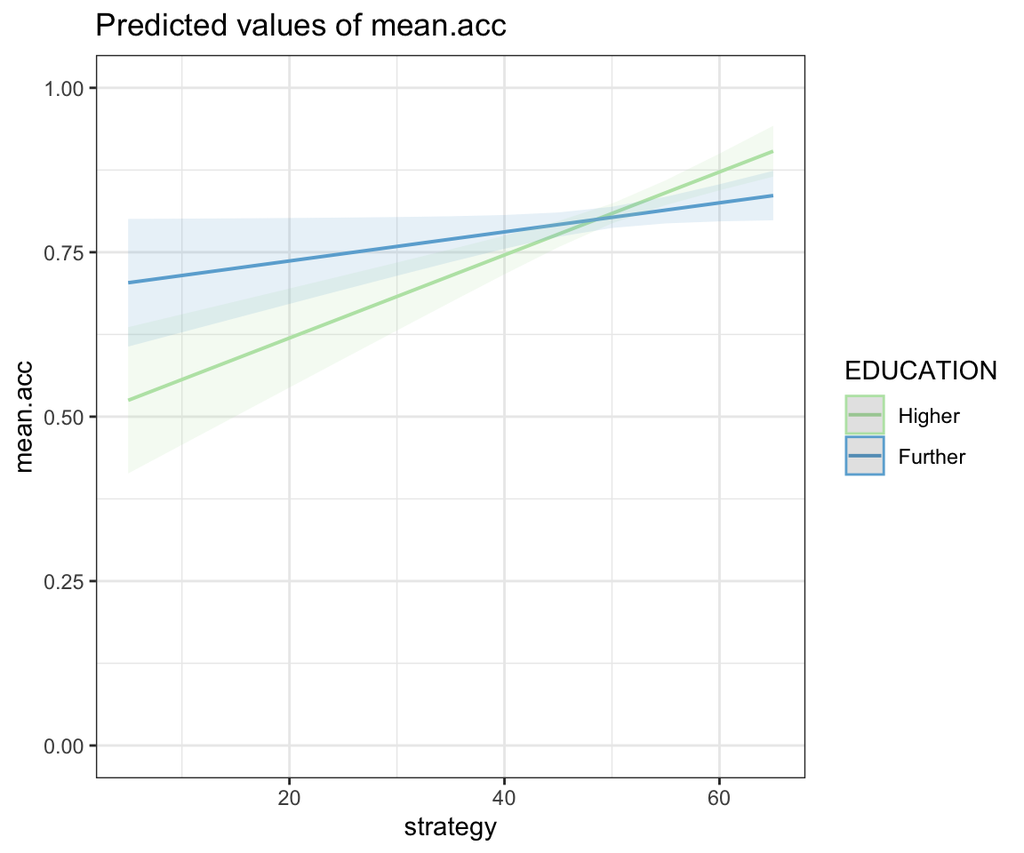

The interaction between the effect of reading strategy on comprehension accuracy and the effect of differences in education level

## Interactions between numeric variables and factors

**Tip**

- While interactions between numeric variables and factors work in the same way
- As the interactions between numeric variables (like `HLVA` and `SHIPLEY`) that we have been working with so far
- You will see **some important differences**

## Interactions between numeric variables and factors

To explore interactions between numeric variables and factors, we take as an example, the interaction between the effect on outcomes (`mean.acc`) of:

- Variation in reading strategy (measured as scores on the `strategy` reading strategy questionnaire), a numeric variable
- Variation in level of education (measured by self-report on `EDUCATION` as `Further` or `Higher`), a factor

## Numeric variables and factors

Two kinds of variables are treated differently in R:

1. **Numeric** variables like health literacy score (`HLVA`) or reading strategy score (`strategy`) where
- the column values are numbers you can do arithmetic with

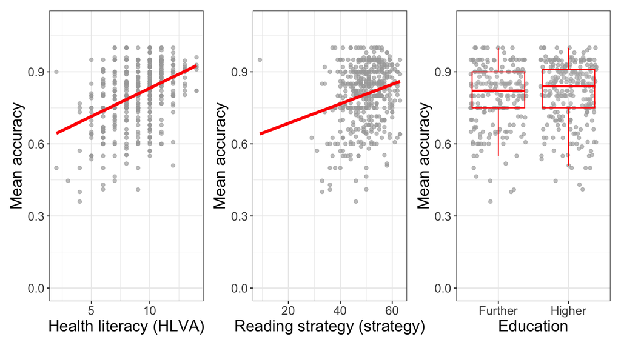

Figure 11: Scatterplots showing the potential association between accuracy of comprehension and variation on (left) health literacy, (middle) reading strategy, or (right) education level

## Numeric variables and factors

Two kinds of variables are treated differently in R:

2. Categorical variables or **factors** like `EDUCATION`
- where values may be numbers or words or letters
- and you use different values to code for group or category e.g. `EDUCATION` level can be `Further` or `Higher`

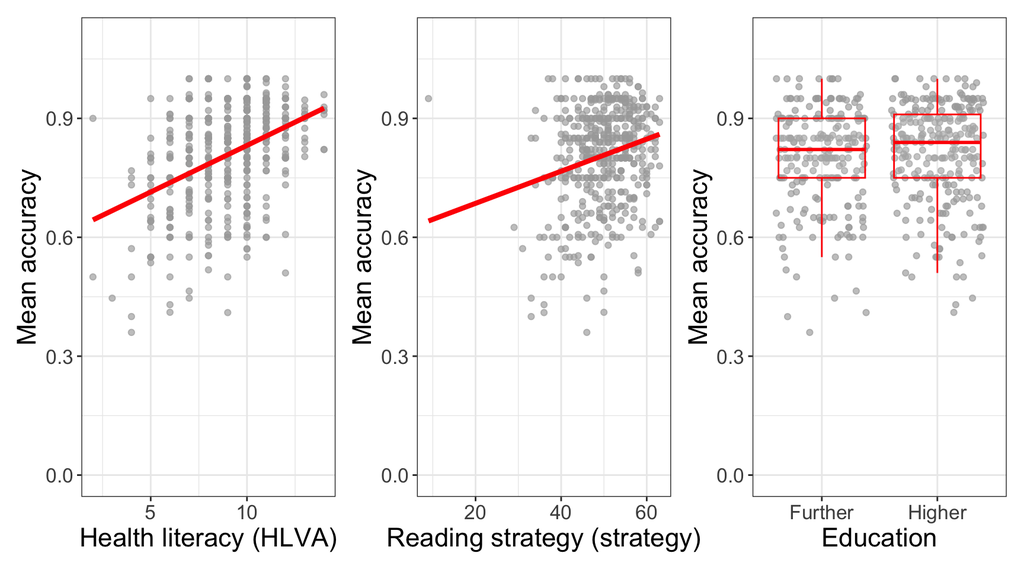

Figure 12: Scatterplots showing the potential association between accuracy of comprehension and variation on (left) health literacy, (middle) reading strategy, or (right) education level

## The effects of factors in linear models

- A factor like `EDUCATION` encodes differences between levels or between groups
- A participant can be coded as having one level only
- A participant can be a member of one group only

```r
data.lm.acc <- lm(mean.acc ~ EDUCATION + strategy,
                  data = all.data)
summary(data.lm.acc)
```

```
Call:
lm(formula = mean.acc ~ EDUCATION + strategy, data = all.data)

Residuals:
     Min       1Q   Median       3Q      Max
-0.42828 -0.06774  0.02177  0.09198  0.31055

Coefficients:
                 Estimate Std. Error t value Pr(>|t|)
(Intercept)     0.6032460  0.0415482  14.519  < 2e-16 ***
EDUCATIONHigher 0.0053666  0.0113014   0.475    0.635
strategy        0.0040226  0.0008266   4.866 1.55e-06 ***
---
Signif. codes:  0 '***' 0.001 '**' 0.01 '*' 0.05 '.' 0.1 ' ' 1

Residual standard error: 0.1229 on 475 degrees of freedom
Multiple R-squared:  0.04889,   Adjusted R-squared:  0.04489
F-statistic: 12.21 on 2 and 475 DF,  p-value: 6.75e-06
```

## The effects of factors in linear models

- If you include a factor like `EDUCATION` in a linear model
- The model will give you an estimate of the effect of differences between the levels of the factor
- R will pick one level as the *baseline* or **reference level**
- and the coefficient estimate will tell you the difference in outcome on average
- between the reference level and the other factor level(-s)

```r
data.lm.acc <- lm(mean.acc ~ EDUCATION + strategy,
                  data = all.data)
summary(data.lm.acc)
```

```
Call:
lm(formula = mean.acc ~ EDUCATION + strategy, data = all.data)

Residuals:
     Min       1Q   Median       3Q      Max
-0.42828 -0.06774  0.02177  0.09198  0.31055

Coefficients:
                 Estimate Std. Error t value Pr(>|t|)
(Intercept)     0.6032460  0.0415482  14.519  < 2e-16 ***
EDUCATIONHigher 0.0053666  0.0113014   0.475    0.635
strategy        0.0040226  0.0008266   4.866 1.55e-06 ***
---
Signif. codes:  0 '***' 0.001 '**' 0.01 '*' 0.05 '.' 0.1 ' ' 1

Residual standard error: 0.1229 on 475 degrees of freedom
Multiple R-squared:  0.04889,   Adjusted R-squared:  0.04489
F-statistic: 12.21 on 2 and 475 DF,  p-value: 6.75e-06
```

## The effects of factors in linear models

- Here, the `Coefficients:` `Estimate` for the effect of `EDUCATION` is `0.0053666`
- The summary shows the coefficient as `EDUCATIONHigher`
- Because the estimate `0.0053666` tells us that
- compared to `Further` education (the reference level)
- people with `Higher` education are predicted to score `0.0053666` more on outcome `mean.acc`

```r
data.lm.acc <- lm(mean.acc ~ EDUCATION + strategy,
                  data = all.data)
summary(data.lm.acc)
```

```
Call:
lm(formula = mean.acc ~ EDUCATION + strategy, data = all.data)

Residuals:
     Min       1Q   Median       3Q      Max
-0.42828 -0.06774  0.02177  0.09198  0.31055

Coefficients:
                 Estimate Std. Error t value Pr(>|t|)
(Intercept)     0.6032460  0.0415482  14.519  < 2e-16 ***
EDUCATIONHigher 0.0053666  0.0113014   0.475    0.635
strategy        0.0040226  0.0008266   4.866 1.55e-06 ***
---
Signif. codes:  0 '***' 0.001 '**' 0.01 '*' 0.05 '.' 0.1 ' ' 1

Residual standard error: 0.1229 on 475 degrees of freedom
Multiple R-squared:  0.04889,   Adjusted R-squared:  0.04489
F-statistic: 12.21 on 2 and 475 DF,  p-value: 6.75e-06
```

## Coding an interaction

We can code the effect of the interaction between the effects of:

- education level (`EDUCATION`)
- reading strategy (`strategy`)

```r
data.lm.acc <- lm(mean.acc ~ EDUCATION*strategy,
                  data = all.data)
summary(data.lm.acc)
```

## What is the interaction term doing?

$$y \sim \beta_0 + \beta_1X + \beta_2Z + \color{red}{\beta_3XZ} + \epsilon$$

$$\begin{aligned}
mean.acc &= {\beta_0} + {\beta}_{1}(EDUCATION_{Higher}) + {\beta}_{2}(strategy)\ + \\
&\quad {\beta}_{3}(EDUCATION_{Higher} \times strategy) + \epsilon
\end{aligned}$$

## What is the interaction term doing?

$$y \sim \beta_0 + \beta_1X + \beta_2Z + \color{red}{\beta_3XZ} + \epsilon$$

$$\begin{aligned}
mean.acc &= {\beta_0} + {\beta}_{1}(EDUCATION_{Higher}) + {\beta}_{2}(strategy)\ + \\
&\quad {\beta}_{3}(EDUCATION_{Higher} \times strategy) + \epsilon
\end{aligned}$$

- $\beta_3$ reflects the **change in the effect** of `strategy` on outcome `mean.acc`
- given different values of `EDUCATION`:
- here, when `EDUCATION` is `Higher` instead of `Further`

## Identifying key information in results: for a model including an interaction

You see each `Estimate` for the `Coefficients:` – the effects of:

1. `EDUCATION`
2. `strategy`
3. The `EDUCATION:strategy` coefficient for the **interaction** tells us how the slope of the `strategy` effect varies – depending on `EDUCATION` level

```r
data.lm.acc <- lm(mean.acc ~ EDUCATION*strategy,
                  data = all.data)
summary(data.lm.acc)
```

```
Call:
lm(formula = mean.acc ~ EDUCATION * strategy, data = all.data)

Residuals:
     Min       1Q   Median       3Q      Max
-0.43422 -0.06111  0.01700  0.09208  0.23754

Coefficients:
                          Estimate Std. Error t value Pr(>|t|)
(Intercept)               0.692571   0.054831  12.631   <2e-16 ***
EDUCATIONHigher          -0.199280   0.083325  -2.392   0.0172 *
strategy                  0.002210   0.001100   2.008   0.0452 *
EDUCATIONHigher:strategy  0.004104   0.001656   2.479   0.0135 *
---
Signif. codes:  0 '***' 0.001 '**' 0.01 '*' 0.05 '.' 0.1 ' ' 1

Residual standard error: 0.1223 on 474 degrees of freedom
Multiple R-squared:  0.06106,   Adjusted R-squared:  0.05512
F-statistic: 10.28 on 3 and 474 DF,  p-value: 1.45e-06
```

## Evaluation of an interaction

Interactions are easier to interpret if we plot them:

1. Fit the model using `lm()`
2. Feed the model estimates into `plot_model()` to show predictions

```r
# -- fit a model
data.lm.acc <- lm(mean.acc ~ EDUCATION*strategy,
                  data = all.data)

# -- set colour values for manual colour
cols.studies <- c("#BAE4B3", "#6BAED6")

# -- make plot
plot_model(data.lm.acc, type = "pred",
           terms = c("strategy", "EDUCATION"),
           colors = cols.studies) +
  theme_bw() +
  ylim(0, 1)
```

## Interactions between numeric variables and factors

The resulting plot shows how the slope of the `strategy` effect is steeper (the effect is larger) for people with `Higher` education than with `Further` education

```r
data.lm.acc <- lm(mean.acc ~ EDUCATION*strategy,
                  data = all.data)
summary(data.lm.acc)
```

```
Call:
lm(formula = mean.acc ~ EDUCATION * strategy, data = all.data)

Residuals:
     Min       1Q   Median       3Q      Max
-0.43422 -0.06111  0.01700  0.09208  0.23754

Coefficients:
                          Estimate Std. Error t value Pr(>|t|)
(Intercept)               0.692571   0.054831  12.631   <2e-16 ***
EDUCATIONHigher          -0.199280   0.083325  -2.392   0.0172 *
strategy                  0.002210   0.001100   2.008   0.0452 *
EDUCATIONHigher:strategy  0.004104   0.001656   2.479   0.0135 *
---
Signif. codes:  0 '***' 0.001 '**' 0.01 '*' 0.05 '.' 0.1 ' ' 1

Residual standard error: 0.1223 on 474 degrees of freedom
Multiple R-squared:  0.06106,   Adjusted R-squared:  0.05512
F-statistic: 10.28 on 3 and 474 DF,  p-value: 1.45e-06
```

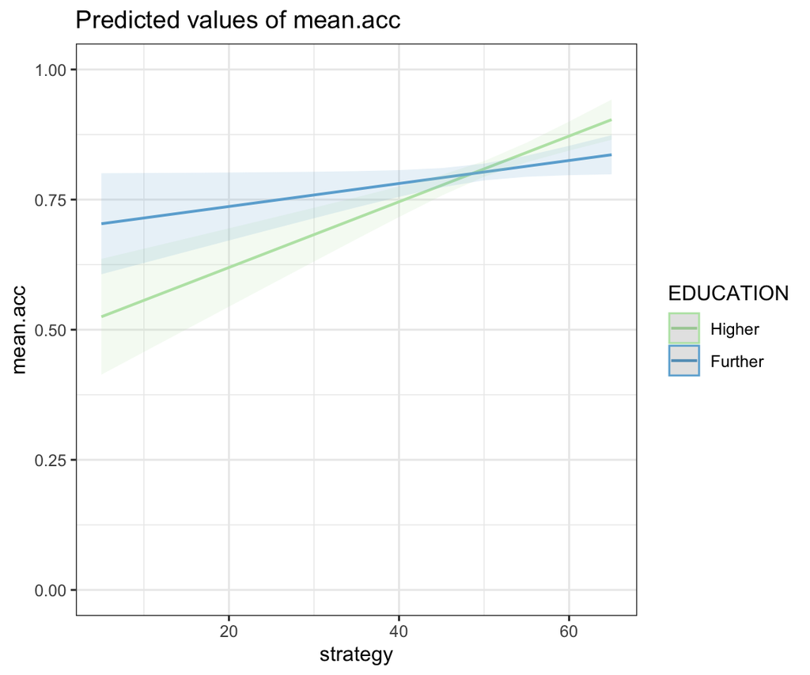

The interaction between the effect of reading strategy on comprehension accuracy and differences in education level

```
Call:
lm(formula = mean.acc ~ EDUCATION * strategy, data = all.data)

Residuals:
     Min       1Q   Median       3Q      Max
-0.43422 -0.06111  0.01700  0.09208  0.23754

Coefficients:
                          Estimate Std. Error t value Pr(>|t|)
(Intercept)               0.692571   0.054831  12.631   <2e-16 ***
EDUCATIONHigher          -0.199280   0.083325  -2.392   0.0172 *
strategy                  0.002210   0.001100   2.008   0.0452 *
EDUCATIONHigher:strategy  0.004104   0.001656   2.479   0.0135 *
---
Signif. codes:  0 '***' 0.001 '**' 0.01 '*' 0.05 '.' 0.1 ' ' 1

Residual standard error: 0.1223 on 474 degrees of freedom
Multiple R-squared:  0.06106,   Adjusted R-squared:  0.05512
F-statistic: 10.28 on 3 and 474 DF,  p-value: 1.45e-06
```

> We fitted a linear model with mean comprehension accuracy as the outcome and education and reading strategy as predictors. The model is significant overall, $F(3, 474) = 10.28, p < .001$, and explains 6% of variance ($\text{adjusted } R^2 = .06$). Accuracy of comprehension was lower for people with higher levels of participant education ($\beta = -.199, t = -2.39, p = .017$). But comprehension was more accurate for people with better reading strategy ($\beta = .002, t = 2.01, p = .045$). A significant interaction ($\beta = .004, t = 2.48, p = .014$) suggests the strategy effect was larger for participant with higher education.

## The language of results reporting: Look at what we do with the text

> We fitted a linear model with mean comprehension accuracy as the outcome and education and reading strategy as predictors. The model is significant overall, $F(3, 474) = 10.28, p < .001$, and explains 6% of variance ($\text{adjusted } R^2 = .06$). Accuracy of comprehension was lower for people with higher levels of participant education ($\beta = -.199, t = -2.39, p = .017$). But comprehension was more accurate for people with better reading strategy ($\beta = .002, t = 2.01, p = .045$). A significant interaction ($\beta = .004, t = 2.48, p = .014$) suggests the strategy effect was larger for participant with higher education.
1. Explain: the method (linear model); the outcome (accuracy) and the predictors
2. Report the model fit statistics overall ($F, R^2$)
3. Report the significant effects ($\beta, t, p$) and describe the effects

## Health comprehension project: answers

**Note**

1. What person attributes predict success in understanding?
- Health literacy, vocabulary, and reading strategy
2. Can people accurately evaluate whether they correctly understand written health information?
- Yes but not very well

## Summary: key lessons

## Understanding key concepts

- Psychologists often assume, or they are interested in, the effects of experimental manipulations, of the effects of treatments or interventions, or the effects of associations between variables
- The key lesson here is that people vary, and effects may vary

## Understanding key concepts

- Effects can be different between different population groups
- Effects can be different for different values of a third variable (that third variable is often called a moderator)
- Where we see that effects are different between different sub-groups or where we see that the effect of an association is different for different levels of a moderator then there we are looking at an *interaction*

## Understanding key coding skills

We typically code models like those we have seen using the structure:

```r
lm(outcome.Y ~ predictor.X*predictor.Z)
```

## End of week 19

## References

Bornstein, M. H., Jager, J., & Putnick, D. L. (2013). Sampling in developmental science: Situations, shortcomings, solutions, and standards. *Developmental Review*, *33*(4), 357–370. https://doi.org/10.1016/j.dr.2013.08.003

Freed, E. M., Hamilton, S. T., & Long, D. L. (2017). Comprehension in proficient readers: The nature of individual variation. *Journal of Memory and Language*, *97*, 135–153. https://doi.org/10.1016/j.jml.2017.07.008

Gelman, A. (2015). The Connection Between Varying Treatment Effects and the Crisis of Unreplicable Research: A Bayesian Perspective. *Journal of Management*, *41*(2), 632–643. https://doi.org/10.1177/0149206314525208

McElreath, R. (2020). *Statistical rethinking*. Chapman; Hall/CRC. https://doi.org/10.1201/9780429029608